# NLP_Assignment_6_SwathiGanesan

## NLP Class Assignment 6

##### NOTEBOOK RUN ON COLAB

```python
!pip install gensim --upgrade
!pip install pyLDAvis --upgrade
!pip install --upgrade ipykernel
```

```python
from google.colab import drive
drive.mount('/content/gdrive')
```

```python
import os
import time
import math
import re
from pprint import pprint
from textblob import TextBlob
import pandas as pd
import numpy as np
import matplotlib.pyplot as plt


import nltk as nltk
from nltk.corpus import stopwords
from nltk.stem.wordnet import WordNetLemmatizer
import spacy
import multiprocessing
import string


import gensim
from gensim import corpora, models
from gensim.models.ldamulticore import LdaMulticore
from gensim.utils import simple_preprocess
from gensim.models import CoherenceModel

import pyLDAvis.gensim
import pyLDAvis
import pyLDAvis.gensim_models as gensimvis
pyLDAvis.enable_notebook()

pd.set_option('display.max_rows', 100)
pd.set_option('display.max_columns', None)
pd.set_option('display.max_colwidth', 500)
```

```python
import nltk
nltk.download('punkt')
nltk.download('stopwords')
nltk.download('wordnet')
```

```
True
```

```python
!pip install pandarallel
import multiprocessing

num_processors = multiprocessing.cpu_count()
print(f'Available CPUs: {num_processors}')

import pandarallel
from pandarallel import pandarallel
pandarallel.initialize(nb_workers=num_processors-1, use_memory_fs=False)
```

```
  Preparing metadata (setup.py) ... done
     ━━━━━━━━━━━━━━━━━━━━━━━━━━━━━━━━━━━━━━━ 110.5/110.5 kB 4.1 MB/s eta 0:00:00
Available CPUs: 40
INFO: Pandarallel will run on 39 workers.
INFO: Pandarallel will use standard multiprocessing data transfer (pipe) to transfer data between the main process and workers.
```

#### Read news data

```python
news_path = 'https://storage.googleapis.com/msca-bdp-data-open/news/nlp_a_6_news.json'
news_df = pd.read_json(news_path, orient='records', lines=True)

print(f'Sample contains {news_df.shape[0]:,.0f} news articles')
news_df.head(2)
```

```
Sample contains 9,962 news articles
```

|  | url | date | language | title | text |
| --- | --- | --- | --- | --- | --- |
| 0 | http://oaklandnewsnow.com/breaking-bts-announces-las-vegas-us-concert-date-in-2022/ | 2022-02-24 | en | BREAKING: BTS Announces LAS VEGAS, US Concert Date in 2022! \| Oakland News Now - Oakland News, SF Bay Area, East Bay, California, World | BREAKING: BTS Announces LAS VEGAS, US Concert Date in 2022! \| Oakland News Now - Oakland News, SF Bay Area, East Bay, California, WorldSorry, you have Javascript Disabled! To see this page as it is m… |
| 1 | http://www.newsdzezimbabwe.co.uk/2022/04/mai-tt-weds.html | 2022-04-09 | en | MAI TT WEDS newsdzeZimbabweNewsdzeZimbabwe | MAI TT WEDS newsdzeZimbabweNewsdzeZimbabweskip to main \| skip to sidebarHomeAboutContactAdvertiseNewsdzeZimbabweOur Zimbabwe Our NewsHomeNewsBusinessEntertainmentSaturday, 9 April 2022MAI TT WEDSSatu… |

```python
news_df.shape
```

```
(9962, 5)
```

```python
# Filter non-English articles
%time news_df = news_df[news_df['language']=='en'].reset_index(drop=True)
```

```
CPU times: user 4.18 ms, sys: 48 µs, total: 4.23 ms
Wall time: 3.89 ms
```

#### Read Tweets data

```python
tweets_path = 'https://storage.googleapis.com/msca-bdp-data-open/tweets/nlp_a_6_tweets.json'
tweets_df = pd.read_json(tweets_path, orient='records', lines=True)
print(f'Sample contains {tweets_df.shape[0]:,.0f} tweets')
tweets_df.head(2)
```

```
Sample contains 9,941 tweets
```

|  | id | lang | date | name | retweeted | text |
| --- | --- | --- | --- | --- | --- | --- |
| 0 | 1484553027222741001 | en | 2022-01-21 | Dylan Green | RT | *Microsoft has entered the chat* https://t.co/Uz3pZrk6B3 |
| 1 | 1505486305102557184 | en | 2022-03-20 | Rahim Rajwani |  | "I actually use an @Android phone. Some #Android manufacturers pre-install @Microsoft software in a way that makes it easy for me. They’re more flexible about how the software connects up with the OS.… |

```python
tweets_df.shape
```

```
(9941, 6)
```

```python
# Filter non-English tweets
%time tweets_df = tweets_df[tweets_df['lang']=='en'].reset_index(drop=True)
```

```
CPU times: user 4.18 ms, sys: 45 µs, total: 4.22 ms
Wall time: 3.65 ms
```

#### Function to clean our input

```python
# Define a function to clean the text data
def clean_text(text, type):
    # Convert to lowercase
    text = text.lower()

    # Remove URLs, mentions, hashtags and newline characters
    text = re.sub(r'http\S+|www.\S+|@\S+|\n', '', text)
    text = re.sub(r'#\w+', '', text)

    if type == "tweet" :
        # Use TweetTokenizer to tokenize
        tweet_tokenizer = nltk.tokenize.TweetTokenizer()
        tokens = tweet_tokenizer.tokenize(text)
    else:
        tokens = nltk.word_tokenize(text)

    # Remove numbers
    #tokens = [token for token in tokens if not token.isnumeric()]

    # Remove punctuation
    tokens = [token for token in tokens if token not in  set(string.punctuation)]

    # Remove all unnecessary characters if any
    tokens = [re.sub(r'[^a-zA-Z0-9 @ . , : - _]', '', token) for token in tokens]

    # Remove stop words and lemmatize the words
    stop_words = set(nltk.corpus.stopwords.words('english'))

    wnl = nltk.WordNetLemmatizer()
    tokens=[wnl.lemmatize(token) for token in tokens if not token in stop_words]

    # Remove single-character tokens (mostly punctuation)
    tokens = [token for token in tokens if len(token) > 1]


    return tokens
```

### Topic Modelling on Tweets

```python
%%time

#tweets_cleaned = tokenize_lemmatize(tweets_df, 'text')

tweets_df['clean_text'] = tweets_df['text'].parallel_apply(lambda x: clean_text(x, "tweet"))
tweets_cleaned = tweets_df['clean_text'].to_list()

# Creating the term dictionary of our courpus, where every unique term is assigned an index.
tweets_dict = corpora.Dictionary(tweets_cleaned)

# Converting list of documents (corpus) into Document Term Matrix using dictionary prepared above.
tweets_doc_term_matrix = [tweets_dict.doc2bow(doc) for doc in tweets_cleaned]
```

```
CPU times: user 549 ms, sys: 1.18 s, total: 1.73 s
Wall time: 6.35 s
```

```python
# supporting function
def compute_coherence_values(corpus, dictionary, data, k, alpha='asymmetric', beta='auto'):
    #Using multicore LDA
    ldamodel = LdaMulticore(corpus=corpus,
                       id2word=dictionary,
                       eta=beta,
                       alpha=alpha,
                       num_topics=k,
                       iterations=100,
                       passes=20,
                       random_state=100,
                       eval_every=None,
                       workers = num_processors-1,
                       per_word_topics=True)

    coherence_model_lda = CoherenceModel(model=ldamodel, texts=data, dictionary=dictionary, coherence='c_v')

    return ldamodel, coherence_model_lda.get_coherence()
```

#### Build initial 3 topic model

```python
%%time

num_topics = 3
tweets_ldamodel, tweets_coherence = compute_coherence_values(corpus=tweets_doc_term_matrix,
                       dictionary=tweets_dict,data=tweets_cleaned,k=num_topics)


print(*tweets_ldamodel.print_topics(num_topics=num_topics, num_words=7), sep='\n')

print('\nCoherence Score: ', tweets_coherence)
```

```
(0, '0.059*"microsoft" + 0.008*"game" + 0.006*"new" + 0.006*"xbox" + 0.005*"activision" + 0.005*"window" + 0.004*"team"')
(1, '0.033*"microsoft" + 0.011*"apple" + 0.010*"premium" + 0.008*"365" + 0.008*"netflix" + 0.007*"grammarly" + 0.007*"account"')
(2, '0.102*"ever" + 0.020*"number" + 0.018*"microsoft" + 0.016*"owns" + 0.014*"know" + 0.012*"10" + 0.008*"started"')

Coherence Score:  0.5170584856562027
CPU times: user 12 s, sys: 4.08 s, total: 16.1 s
Wall time: 14.7 s
```

```python
%%time

lda_display = gensimvis.prepare(tweets_ldamodel, tweets_doc_term_matrix, tweets_dict, sort_topics=False, mds='mmds')
pyLDAvis.display(lda_display)
```

```
CPU times: user 2.03 s, sys: 1.17 s, total: 3.2 s
Wall time: 3.92 s
```

[interactive chart not shown]

[figure not shown]

From the topics and the pyLDAvis we can observe that all the tweets are about Microsoft, but N is too small to clearly determine individual topics. Let us try a larger value.

#### Ten-topic Model

```python
%%time

num_topics = 10
tweets_ldamodel, tweets_coherence = compute_coherence_values(corpus=tweets_doc_term_matrix,
                       dictionary=tweets_dict,data=tweets_cleaned,k=num_topics)


print(*tweets_ldamodel.print_topics(num_topics=num_topics, num_words=7), sep='\n')

print('\nCoherence Score: ', tweets_coherence)
```

```
(0, '0.065*"microsoft" + 0.010*"new" + 0.008*"window" + 0.007*"team" + 0.005*"azure" + 0.005*"xbox" + 0.005*"billion"')
(1, '0.052*"microsoft" + 0.006*"apple" + 0.006*"google" + 0.005*"..." + 0.005*"get" + 0.005*"technology" + 0.005*"world"')
(2, '0.036*"microsoft" + 0.018*"premium" + 0.015*"365" + 0.014*"know" + 0.014*"grammarly" + 0.014*"netflix" + 0.013*"canva"')
(3, '0.109*"ever" + 0.046*"microsoft" + 0.012*"like" + 0.008*"year" + 0.007*"look" + 0.007*"word" + 0.005*"designed"')
(4, '0.044*"microsoft" + 0.008*"game" + 0.008*"like" + 0.006*"one" + 0.005*"company" + 0.005*"get" + 0.005*"month"')
(5, '0.056*"microsoft" + 0.034*"game" + 0.020*"xbox" + 0.018*"buy" + 0.014*"activision" + 0.014*"sony" + 0.013*"playstation"')
(6, '0.038*"microsoft" + 0.028*"number" + 0.023*"owns" + 0.013*"started" + 0.012*"google" + 0.008*"free" + 0.008*"2021"')
(7, '0.019*"microsoft" + 0.008*"like" + 0.007*"time" + 0.007*"excel" + 0.007*"feel" + 0.006*"know" + 0.006*"net"')
(8, '0.029*"stop" + 0.027*"microsoft" + 0.024*"russia" + 0.024*"product" + 0.014*"support" + 0.012*"war" + 0.011*"supporting"')
(9, '0.014*"microsoft" + 0.010*"free" + 0.006*"adobe" + 0.005*"..." + 0.005*"tutorial" + 0.005*"one" + 0.004*"tuts"')

Coherence Score:  0.44084809455802815
CPU times: user 14.1 s, sys: 4.48 s, total: 18.5 s
Wall time: 17.2 s
```

```python
%%time

lda_display = gensimvis.prepare(tweets_ldamodel, tweets_doc_term_matrix, tweets_dict, sort_topics=False, mds='mmds')
pyLDAvis.display(lda_display)
```

```
CPU times: user 2.49 s, sys: 66.8 ms, total: 2.56 s
Wall time: 4.02 s
```

[interactive chart not shown]

[figure not shown]

It is evident that we are able to see better distinct topics as N increased. However with just a coherence score of 0.44 we can also see an overlap in the obtained topics. In order to find the best N, we can perform Hyper parameter tuning.

#### Tune LDA model

To find the optimal number of topics (N) for LDA, you can use the coherence score method. The coherence score measures the degree of semantic similarity between high-scoring words in a topic. The coherence score is calculated based on the top words of each topic, so higher coherence scores indicate better-defined topics.

We will be tuning alpha, beta and number of topics as follows :

```python
%%time
# Define the range of values for the number of topics to try
min_topics = 2
max_topics = 12
step_size = 1
topics_range = range(min_topics, max_topics+1, step_size)

# Alpha parameter
#alpha = ['asymmetric'] # Run for number of topics only
alpha = list(np.arange(0.01, 1, 0.3))
alpha.append('symmetric')
alpha.append('asymmetric')

# Beta parameter
#beta = ['auto'] # Run for number of topics only
beta = list(np.arange(0.01, 1, 0.3))
beta.append('symmetric')

itr = 0
itr_total = len(beta)*len(alpha)*len(topics_range)
print(f'LDA will execute {itr_total} iterations')

# Create lists to store the coherence scores and the corresponding models
coherence_scores = []
models = []
model_results = {
                 'Topics': [],
                 'Alpha': [],
                 'Beta': [],
                 'Coherence': []
                }


# Iterate over the number of topics to try
for num_topics in topics_range:
    for a in alpha:
        for b in beta:
            itr += 1

            tune_ldamodel, tune_coherence = compute_coherence_values(corpus=tweets_doc_term_matrix,
                           dictionary=tweets_dict,data=tweets_cleaned,k=num_topics,alpha=a,beta=b)


            # Store the coherence score and the corresponding model
            coherence_scores.append(tune_coherence)
            models.append(tune_ldamodel)

            # Save the model results
            model_results['Topics'].append(num_topics)
            model_results['Alpha'].append(a)
            model_results['Beta'].append(b)
            model_results['Coherence'].append(tune_coherence)
            pct_completed = round((itr / itr_total * 100),1)
    print(f'Completed model based on {num_topics} LDA topics. Finished {pct_completed}% of LDA runs')


lda_tuning = pd.DataFrame(model_results)
# create a file in your Google Drive
lda_tuning.to_csv('/content/gdrive/My Drive/model/lda_tweets_tuning.csv', index=False)

# Find the model with the highest coherence score
best_model_index = np.argmax(coherence_scores)
best_model = models[best_model_index]
# save the model
best_model.save('/content/gdrive/My Drive/model/lda_tweet_best_model.ldamodel')
```

```python
tweets_tuning = pd.read_csv('/content/gdrive/My Drive/model/lda_tweets_tuning.csv')
tweet_best_model = LdaMulticore.load('/content/gdrive/My Drive/model/lda_tweet_best_model.ldamodel')

best_num_topics = tweets_tuning.sort_values(by=['Coherence'], ascending=False).head(1)['Topics'].values[0]
best_coherence = tweets_tuning.sort_values(by=['Coherence'], ascending=False).head(1)['Coherence'].values[0]
print(f'The best number of topics is {best_num_topics} with a coherence score of {best_coherence}')
```

```
The best number of topics is 6 with a coherence score of 0.7136335852373045
```

```python
# Best LDA parameters
tweets_tuning.sort_values(by=['Coherence'], ascending=False).head(10)
```

|  | Topics | Alpha | Beta | Coherence |
| --- | --- | --- | --- | --- |
| 148 | 6 | asymmetric | 0.9099999999999999 | 0.713634 |
| 237 | 9 | asymmetric | 0.61 | 0.683856 |
| 58 | 3 | asymmetric | 0.9099999999999999 | 0.674784 |
| 328 | 12 | asymmetric | 0.9099999999999999 | 0.667382 |
| 238 | 9 | asymmetric | 0.9099999999999999 | 0.665258 |
| 298 | 11 | asymmetric | 0.9099999999999999 | 0.663146 |
| 208 | 8 | asymmetric | 0.9099999999999999 | 0.660321 |
| 267 | 10 | asymmetric | 0.61 | 0.644711 |
| 118 | 5 | asymmetric | 0.9099999999999999 | 0.642668 |
| 178 | 7 | asymmetric | 0.9099999999999999 | 0.629430 |

```python
print(*tweet_best_model.print_topics(num_topics=6, num_words=10), sep='\n')
```

```
(0, '0.055*"microsoft" + 0.007*"game" + 0.006*"new" + 0.005*"xbox" + 0.005*"like" + 0.005*"activision" + 0.004*"window" + 0.004*"team" + 0.004*"company" + 0.004*"get"')
(1, '0.020*"microsoft" + 0.009*"premium" + 0.007*"apple" + 0.007*"365" + 0.007*"grammarly" + 0.007*"netflix" + 0.007*"canva" + 0.006*"spotify" + 0.006*"account" + 0.006*"quillbot"')
(2, '0.010*"know" + 0.008*"microsoft" + 0.006*"10" + 0.005*"world" + 0.005*"basic" + 0.005*"used" + 0.005*"dont" + 0.005*"excel" + 0.005*"people" + 0.005*"use"')
(3, '0.075*"ever" + 0.015*"number" + 0.011*"owns" + 0.006*"microsoft" + 0.006*"started" + 0.004*"google" + 0.004*"twitter" + 0.003*"facebook" + 0.003*"400" + 0.003*"10"')
(4, '0.002*"ceo" + 0.001*"tesla" + 0.001*"ceogoogle" + 0.001*"ceopaypal" + 0.001*"ceoapple" + 0.001*"ceomicrosoft" + 0.001*"ceouber" + 0.001*"ceoairbnb" + 0.001*"worst" + 0.001*"people"')
(5, '0.001*"removed" + 0.001*"highrisk" + 0.001*"lockdown" + 0.001*"older" + 0.001*"assignment" + 0.001*"saved" + 0.001*"focused" + 0.001*"erased" + 0.001*"argued" + 0.001*"rewriting"')
```

```python
%%time

lda_display = gensimvis.prepare(tweet_best_model, tweets_doc_term_matrix, tweets_dict, sort_topics=False, mds='mmds')
# Generate the HTML visualization
pyLDAvis.save_html(lda_display, '/content/gdrive/My Drive/model/tweets_lda_visualization.html')
pyLDAvis.display(lda_display)
```

```
CPU times: user 1.76 s, sys: 102 ms, total: 1.86 s
Wall time: 3.02 s
```

[interactive chart not shown]

[figure not shown]

The identified topics in tweets in tandem with Microsoft using N=6 are

- Topic 1 : Video games and gaming (Games, Sony, Xbox, Activision)
- Topic 2 : Tech companies and products (Apple, Grammarly, Netflix, Canva, Spotify, and Quillbot)
- Topic 3 : Microsoft Products (Microsoft, 365, Excel)
- Topic 4 : Business and Media (Facebook, Twitter, Google, Owns, Richest, Guy, Forbes, Bloomberg, Washington Post)
- Topic 5 : CEO related tweets
- Topic 6 : Very low weights assigned to its keywords, indicating that it may not be a significant or well-defined topic in the corpus. The keywords in this topic also appear to be somewhat unrelated and do not form a clear topic. It is possible that this topic was generated due to noise or other factors in the data.

### Topic Modelling on News

```python
%%time

news_df['clean_text'] = news_df['text'].parallel_apply(lambda x: clean_text(x, "text"))
news_cleaned = news_df['clean_text'].to_list()

# Creating the term dictionary of our courpus, where every unique term is assigned an index.
news_dict = corpora.Dictionary(news_cleaned)

# Converting list of documents (corpus) into Document Term Matrix using dictionary prepared above.
news_doc_term_matrix = [news_dict.doc2bow(doc) for doc in news_cleaned]
```

```
CPU times: user 22.4 s, sys: 2.67 s, total: 25 s
Wall time: 37.8 s
```

#### Build initial 3 topic model

```python
%%time

num_topics = 3
news_ldamodel, news_coherence = compute_coherence_values(corpus=news_doc_term_matrix,
                       dictionary=news_dict,data=news_cleaned,k=num_topics)


print(*news_ldamodel.print_topics(num_topics=num_topics, num_words=7), sep='\n')

print('\nCoherence Score: ', news_coherence)
```

```
(0, '0.017*"video" + 0.014*"music" + 0.014*"official" + 0.012*"2022" + 0.008*"news" + 0.006*"new" + 0.006*"song"')
(1, '0.006*"market" + 0.004*"company" + 0.004*"2022" + 0.004*"new" + 0.003*"stock" + 0.003*"news" + 0.003*"data"')
(2, '0.008*"new" + 0.004*"open" + 0.004*"..." + 0.004*"best" + 0.004*"tab" + 0.003*"game" + 0.003*"show"')

Coherence Score:  0.4742804448485525
CPU times: user 3min 8s, sys: 24.3 s, total: 3min 33s
Wall time: 5min 7s
```

```python
%%time

lda_display = gensimvis.prepare(news_ldamodel, news_doc_term_matrix, news_dict, sort_topics=False, mds='mmds')
pyLDAvis.display(lda_display)
```

```
CPU times: user 1min 7s, sys: 7min 33s, total: 8min 40s
Wall time: 28.8 s
```

[interactive chart not shown]

[figure not shown]

N is too small to distinctly identify topics in the news data. We can try for larger values of N.

#### Ten-topic Model

```python
%%time

num_topics = 10
news_ldamodel, news_coherence = compute_coherence_values(corpus=news_doc_term_matrix,
                       dictionary=news_dict,data=news_cleaned,k=num_topics)


print(*news_ldamodel.print_topics(num_topics=num_topics, num_words=7), sep='\n')

print('\nCoherence Score: ', news_coherence)
```

```
(0, '0.007*"stock" + 0.005*"price" + 0.004*"share" + 0.004*"company" + 0.003*"data" + 0.003*"holding" + 0.003*"news"')
(1, '0.007*"stock" + 0.005*"company" + 0.005*"market" + 0.004*"day" + 0.003*"2022" + 0.003*"may" + 0.003*"news"')
(2, '0.015*"0.75pt" + 0.014*"new" + 0.013*"style" + 0.013*"open" + 0.012*"link" + 0.012*"tab" + 0.011*"td"')
(3, '0.043*"2022" + 0.025*"pm" + 0.006*"new" + 0.005*"10" + 0.004*"game" + 0.004*"india" + 0.003*"2021"')
(4, '0.008*"new" + 0.006*"share" + 0.006*"best" + 0.005*"game" + 0.005*"company" + 0.004*"stock" + 0.004*"get"')
(5, '0.009*"market" + 0.005*"2022" + 0.004*"said" + 0.004*"news" + 0.004*"new" + 0.003*"ago" + 0.003*"company"')
(6, '0.010*"market" + 0.008*"news" + 0.007*"equity" + 0.007*"password" + 0.006*"company" + 0.006*"..." + 0.006*"account"')
(7, '0.007*"..." + 0.005*"new" + 0.004*"show" + 0.004*"star" + 0.004*"say" + 0.003*"day" + 0.003*"year"')
(8, '0.025*"video" + 0.022*"music" + 0.021*"official" + 0.011*"2022" + 0.009*"news" + 0.009*"song" + 0.007*"oakland"')
(9, '0.016*"cookie" + 0.014*"de" + 0.010*"la" + 0.008*"used" + 0.008*"set" + 0.007*"user" + 0.006*"que"')

Coherence Score:  0.45036198692796836
CPU times: user 6min 5s, sys: 45.3 s, total: 6min 50s
Wall time: 13min 8s
```

```python
%%time

lda_display = gensimvis.prepare(news_ldamodel, news_doc_term_matrix, news_dict, sort_topics=False, mds='mmds')
pyLDAvis.display(lda_display)
```

```
CPU times: user 2min 9s, sys: 13min 40s, total: 15min 50s
Wall time: 51.3 s
```

[interactive chart not shown]

[figure not shown]

#### Tune LDA model

```
LDA will execute 9 iterations
Completed model based on 4 LDA topics. Finished 11.1% of LDA runs
Completed model based on 5 LDA topics. Finished 22.2% of LDA runs
Completed model based on 6 LDA topics. Finished 33.3% of LDA runs
Completed model based on 7 LDA topics. Finished 44.4% of LDA runs
Completed model based on 8 LDA topics. Finished 55.6% of LDA runs
Completed model based on 9 LDA topics. Finished 66.7% of LDA runs
Completed model based on 10 LDA topics. Finished 77.8% of LDA runs
Completed model based on 11 LDA topics. Finished 88.9% of LDA runs
Completed model based on 12 LDA topics. Finished 100.0% of LDA runs
```

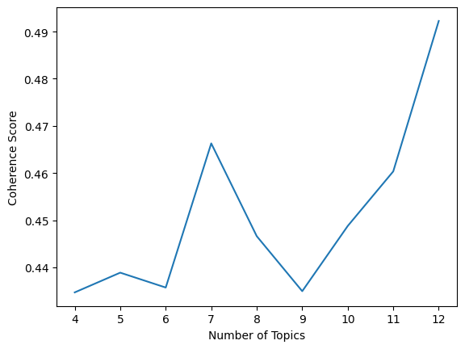

```
CPU times: user 37min 10s, sys: 5min 19s, total: 42min 29s
Wall time: 1h 14min 57s
```

```python
%%time
# Define the range of values for the number of topics to try
min_topics = 4
max_topics = 12
step_size = 1
topics_range = range(min_topics, max_topics+1, step_size)


itr = 0
itr_total = len(topics_range)
print(f'LDA will execute {len(topics_range)} iterations')

# Create lists to store the coherence scores and the corresponding models
coherence_scores = []
models = []
model_results = {
                 'Topics': [],
                 'Coherence': []
                }


# Iterate over the number of topics to try
for num_topics in topics_range:
    itr += 1

    #tune_ldamodel, tune_coherence = compute_coherence_values(corpus=news_doc_term_matrix,dictionary=news_dict,data=news_cleaned,k=num_topics)
    tune_ldamodel = LdaMulticore(corpus=news_doc_term_matrix,
                       id2word=news_dict,
                       num_topics=num_topics,
                       passes=20,
                       random_state=100,
                       eval_every=None,
                       workers = num_processors-1,
                       per_word_topics=True)

    coherence_model_lda = CoherenceModel(model=tune_ldamodel, texts=news_cleaned, dictionary=news_dict, coherence='c_v')
    tune_coherence = coherence_model_lda.get_coherence()

    # Store the coherence score and the corresponding model
    coherence_scores.append(tune_coherence)
    models.append(tune_ldamodel)

    # Save the model results
    model_results['Topics'].append(num_topics)
    model_results['Coherence'].append(tune_coherence)
    pct_completed = round((itr / itr_total * 100),1)
    print(f'Completed model based on {num_topics} LDA topics. Finished {pct_completed}% of LDA runs')

# Plot the coherence scores as a function of the number of topics
plt.plot(topics_range, coherence_scores)
plt.xlabel('Number of Topics')
plt.ylabel('Coherence Score')
plt.show()


lda_tuning = pd.DataFrame(model_results)
# create a file in your Google Drive
lda_tuning.to_csv('/content/gdrive/My Drive/model/lda_news_tuning.csv', index=False)

# Find the model with the highest coherence score
best_model_index = np.argmax(coherence_scores)
best_model = models[best_model_index]
# save the model
best_model.save('/content/gdrive/My Drive/model/lda_news_best_model.ldamodel')
```

```python
news_tuning = pd.read_csv('/content/gdrive/My Drive/model/lda_news_tuning.csv')
news_best_model = LdaMulticore.load('/content/gdrive/My Drive/model/lda_news_best_model.ldamodel')

best_num_topics = news_tuning.sort_values(by=['Coherence'], ascending=False).head(1)['Topics'].values[0]
best_coherence = news_tuning.sort_values(by=['Coherence'], ascending=False).head(1)['Coherence'].values[0]
print(f'The best number of topics is {best_num_topics} with a coherence score of {best_coherence}')
```

```
The best number of topics is 12 with a coherence score of 0.4922625586160243
```

```python
# Best LDA parameters
news_tuning.sort_values(by=['Coherence'], ascending=False).head(10)
```

|  | Topics | Coherence |
| --- | --- | --- |
| 8 | 12 | 0.492263 |
| 3 | 7 | 0.466294 |
| 7 | 11 | 0.460352 |
| 6 | 10 | 0.448778 |
| 4 | 8 | 0.446613 |
| 1 | 5 | 0.438874 |
| 2 | 6 | 0.435716 |
| 5 | 9 | 0.434943 |
| 0 | 4 | 0.434689 |

```python
print(*news_best_model.print_topics(num_topics=best_num_topics, num_words=10), sep='\n')
```

```
(0, '0.014*"stock" + 0.006*"market" + 0.006*"price" + 0.005*"news" + 0.005*"traded" + 0.005*"trading" + 0.004*"dollar" + 0.003*"inc." + 0.003*"last" + 0.003*"report"')
(1, '0.007*"stock" + 0.005*"market" + 0.005*"rate" + 0.004*"say" + 0.004*"price" + 0.004*"new" + 0.004*"year" + 0.004*"billion" + 0.004*"inflation" + 0.004*"u.s."')
(2, '0.014*"0.75pt" + 0.013*"new" + 0.013*"style" + 0.013*"open" + 0.012*"link" + 0.012*"tab" + 0.011*"td" + 0.008*"font" + 0.007*"people" + 0.006*"news"')
(3, '0.051*"2022" + 0.030*"pm" + 0.007*"new" + 0.006*"10" + 0.004*"game" + 0.004*"2021" + 0.004*"apple" + 0.003*"28" + 0.003*"11" + 0.003*"20"')
(4, '0.008*"new" + 0.007*"share" + 0.006*"best" + 0.006*"game" + 0.005*"company" + 0.004*"stock" + 0.004*"get" + 0.004*"inc." + 0.003*"one" + 0.003*"also"')
(5, '0.014*"market" + 0.005*"business" + 0.005*"2022" + 0.005*"company" + 0.004*"report" + 0.004*"global" + 0.004*"service" + 0.004*"data" + 0.004*"technology" + 0.004*"growth"')
(6, '0.011*"market" + 0.008*"news" + 0.007*"equity" + 0.007*"password" + 0.007*"company" + 0.006*"account" + 0.006*"data" + 0.005*"stock" + 0.005*"nasdaq" + 0.005*"financial"')
(7, '0.008*"..." + 0.005*"new" + 0.005*"show" + 0.004*"star" + 0.004*"say" + 0.003*"look" + 0.003*"year" + 0.003*"first" + 0.003*"day" + 0.003*"nt"')
(8, '0.005*"company" + 0.005*"market" + 0.005*"symbol" + 0.005*"2022" + 0.004*"news" + 0.004*"group" + 0.004*"new" + 0.004*"medium" + 0.003*"gray" + 0.003*"data"')
(9, '0.015*"cookie" + 0.014*"de" + 0.010*"la" + 0.008*"used" + 0.007*"set" + 0.007*"user" + 0.006*"que" + 0.006*"en" + 0.006*"time" + 0.006*"website"')
(10, '0.009*"ago" + 0.007*"said" + 0.006*"2022" + 0.006*"time" + 0.005*"news" + 0.005*"hour" + 0.004*"day" + 0.004*"state" + 0.004*"new" + 0.003*"world"')
(11, '0.026*"video" + 0.022*"music" + 0.021*"official" + 0.011*"2022" + 0.009*"song" + 0.009*"news" + 0.008*"oakland" + 0.007*"new" + 0.005*"black" + 0.005*"nfl"')
```

[figure not shown]

```python
%%time

lda_display = gensimvis.prepare(news_best_model, news_doc_term_matrix, news_dict, sort_topics=False, mds='mmds')
# Generate the HTML visualization
pyLDAvis.save_html(lda_display, '/content/gdrive/My Drive/model/news_lda_visualization.html')
pyLDAvis.display(lda_display)
```

```
CPU times: user 1min 47s, sys: 11min 14s, total: 13min 1s
Wall time: 45.8 s
```

[interactive chart not shown]

As there is not a lot of significant difference in the coherence scores and since N=12 has a lot of duplicates, we can observe the local maxima N=7. Let us look into the results for this parameter.

#### Finetuning the model to get the best topics with minimal duplication

```python
%%time

num_topics = 7

news_ldamodel = LdaMulticore(corpus=news_doc_term_matrix,
                       id2word=news_dict,
                       num_topics=num_topics,
                       passes=20,
                       random_state=100,
                       eval_every=None,
                       workers = num_processors-1,
                       per_word_topics=True)

coherence_model_lda = CoherenceModel(model=news_ldamodel, texts=news_cleaned, dictionary=news_dict, coherence='c_v')
news_coherence = coherence_model_lda.get_coherence()



print(*news_ldamodel.print_topics(num_topics=num_topics, num_words=7), sep='\n')

print('\nCoherence Score: ', news_coherence)
```

```
(0, '0.025*"video" + 0.022*"music" + 0.021*"official" + 0.011*"2022" + 0.009*"news" + 0.009*"song" + 0.007*"oakland"')
(1, '0.005*"stock" + 0.005*"market" + 0.004*"new" + 0.003*"news" + 0.003*"say" + 0.003*"company" + 0.003*"said"')
(2, '0.008*"new" + 0.005*"..." + 0.004*"style" + 0.004*"0.75pt" + 0.004*"show" + 0.004*"link" + 0.004*"open"')
(3, '0.022*"2022" + 0.018*"de" + 0.015*"pm" + 0.014*"la" + 0.008*"que" + 0.008*"en" + 0.007*"el"')
(4, '0.007*"new" + 0.006*"share" + 0.005*"best" + 0.005*"company" + 0.005*"game" + 0.004*"stock" + 0.004*"2022"')
(5, '0.009*"market" + 0.006*"2022" + 0.005*"ago" + 0.004*"said" + 0.004*"news" + 0.004*"time" + 0.004*"service"')
(6, '0.017*"cookie" + 0.008*"used" + 0.008*"set" + 0.008*"user" + 0.007*"data" + 0.006*"website" + 0.005*"market"')

Coherence Score:  0.4662938602263441
CPU times: user 3min 55s, sys: 36.6 s, total: 4min 32s
Wall time: 7min 33s
```

```python
%%time

lda_display = gensimvis.prepare(news_ldamodel, news_doc_term_matrix, news_dict, sort_topics=False, mds='mmds')
pyLDAvis.save_html(lda_display, '/content/gdrive/My Drive/model/news_lda_visualization_7.html')
pyLDAvis.display(lda_display)
```

```
CPU times: user 1min 37s, sys: 10min 40s, total: 12min 17s
Wall time: 33.6 s
```

[interactive chart not shown]

[figure not shown]

We can observe good distinct topics from the viz. By taking a deeper look into the terms in each topic we can identify the topis as follows

- Topic 1: Entertainment news (videos, music, etc.)
- Topic 2: Financial and business news (stocks, markets, etc.)
- Topic 3: Formatting and styling
- Topic 4: International news, potentially in a Spanish-speaking country or region
- Topic 5: Technology and Company news (stocks, prices, etc.)
- Topic 6: General news (markets, services, business, etc.)
- Topic 7: Online tracking and privacy, esp. the use of cookies on websites. (cookie, used, set, user, and data)

## For Tweets N = 6 & News articles N = 7

#### PLEASE FIND INDIVIDUAL .html FILES W THE pyLDAvis FOR NEWS AND TWEETS WITH THE BEST N